# Simulate dose titration in the model

Metrum Research Group, LLC

# 1 The model

# 2 The titration scheme

- Everyone gets 100 mg q12h for a week
- After that, start monitoring the trough response and adjust doses according to a dosing protocol
  - `118 < RESP < 122` keep the dose the same
  - `122 < RESP < 150` decrease by 20%
  - `RESP > 150` decrease by 40%
  - `105 < RESP < 118` increase by 30%
  - `RESP < 105` double the dose
- Implement the titration protocol for six weeks and summarize baseline and final response at week 10

# 3 To investigate

- Summarize the distribution of final responses relative to baseline responses both with and without the dose titration scheme in play

## 3.1 A twist to try out

- Instead of adjusting the dose based on the trough response, try adjusting the dose based on the mean of the last 3 daily response measurements

# 4 Setup

```r
library(mrgsolve)
library(dplyr)
library(ggplot2)
library(tidyr)
```

We have written more code

```r
code <- '
$SET req = ""

$GLOBAL
double F1  = 1;

double adjust(double resp, double F1) {
  if(resp > 118 && resp < 122) return F1;
  if(resp > 122 && resp < 150) return F1 * 0.8;
  if(resp > 150) return F1 * 0.6;
  if(resp > 105 && resp < 118) return F1 * 1.3;
  if(resp < 105) return F1 * 2;
  return F1;
}

$PARAM
TVCL = 1, V = 20, KA = 1.2,
TVEC50 = 20, TVE0 = 100
TITR = 1

$PKMODEL cmt = "GUT CENT", depot = TRUE

$OMEGA 0 0.09 100

$MAIN

if(NEWIND <=1 ) F1 = 1;
double CL = TVCL*exp(ETA(1));
double EC50 = TVEC50*exp(ETA(2));
double E0 = TVE0 + ETA(3);

F_GUT = F1;

$TABLE
capture CP = CENT/V;
capture RESP = E0 + 60*CP/(EC50+CP);

if(TIME/168 == floor(TIME/168)) {
  if(EVID==0 && TIME > 7*24 && TIME <= 7*7*24 && TITR==1) {
    F1 = adjust(RESP,F1);
  }
}

capture F1out = F1;

'
```

The simulation duration

```r
dur <- 10*7*24
```

```r
mod <-
  mcode("foo", code) %>%
  update(end = dur) %>%
  ev(amt=100, ii=12, addl=2*10*7)

mod <- param(mod, TITR = 1)
```

## 4.1 Simulate 50 individuals

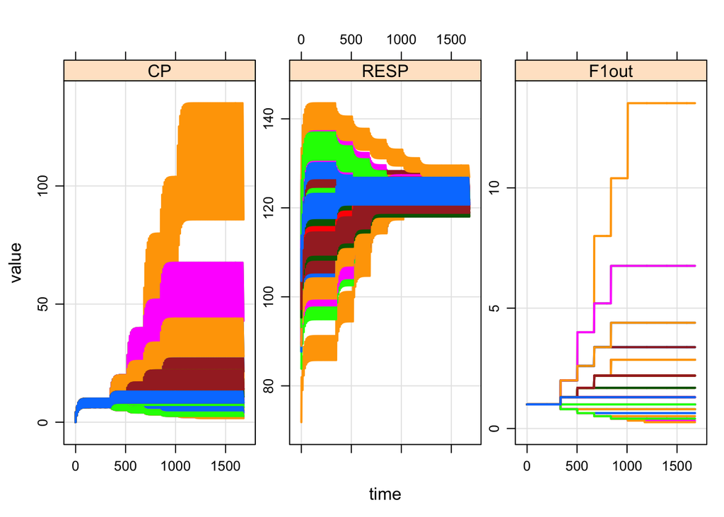

```r
set.seed(102214)
out <- mrgsim(mod, nid = 50, delta = 2, obsonly = TRUE)
plot(out)
```

## 4.2 Summarize the simulations

- Just get the rows at baseline and at the end
- Derive a `variable` column for plotting

```r
sum <-
  filter(out, time %in% c(0,dur)) %>%
  group_by(ID) %>% mutate(variable = c("Baseline", "Week 10"))
```

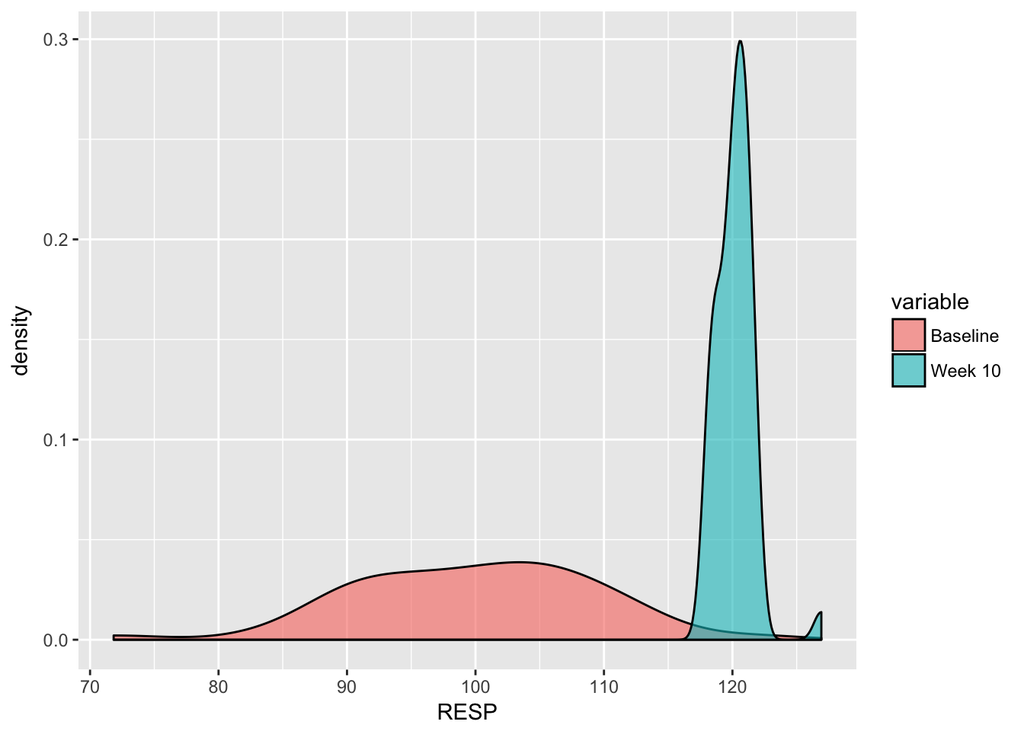

```r
ggplot(data=sum) +
  geom_density(aes(x=RESP, fill=variable), alpha = 0.6)
```

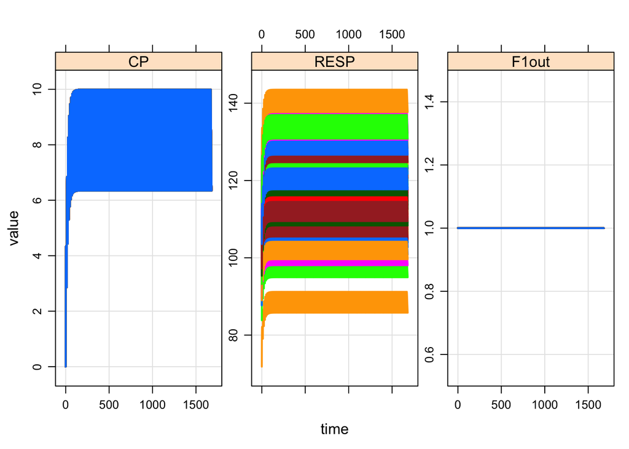

```r
set.seed(102214)
out <-
  mod %>% param(TITR = 0) %>%
  mrgsim(nid = 50, delta = 1, obsonly = TRUE)

plot(out)
```

```r
sum <-
  filter(out, time %in% c(0,dur)) %>%
  group_by(ID) %>% mutate(variable = c("Baseline", "Week 10"))
```

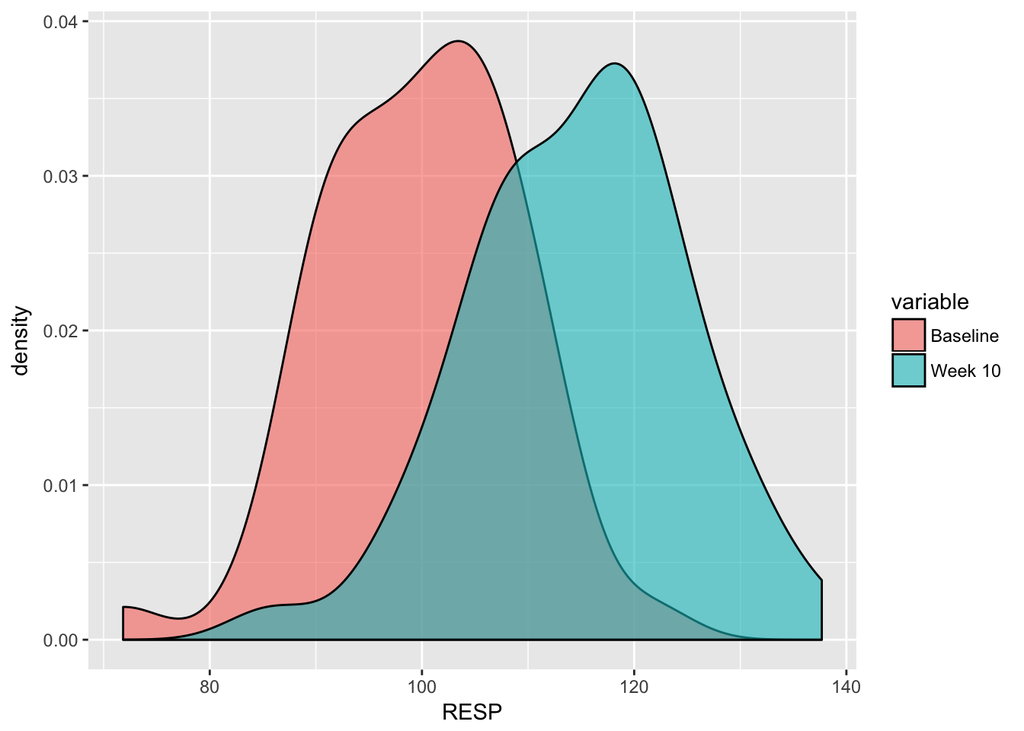

```r
ggplot(data=sum) +
  geom_density(aes(x=RESP, fill=variable), alpha = 0.6)
```